# Visualisierungen

## Horizontale und vertikale Facetten

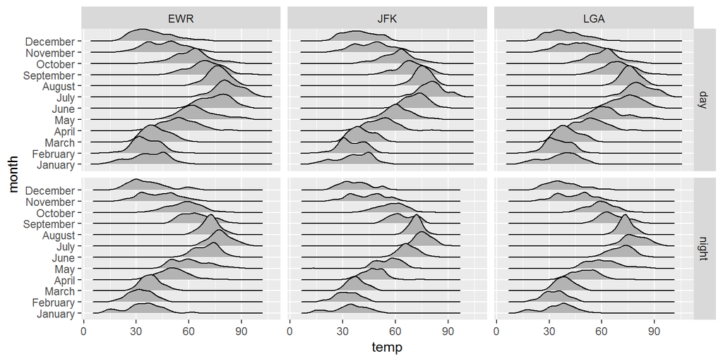

```r
weather_fac %>%
  ggplot(aes(x=temp, y=month)) +
    ggridges::geom_density_ridges() +
    facet_grid(time~origin)
```

## facet_wrap() nutzt h&v für einen Faktor

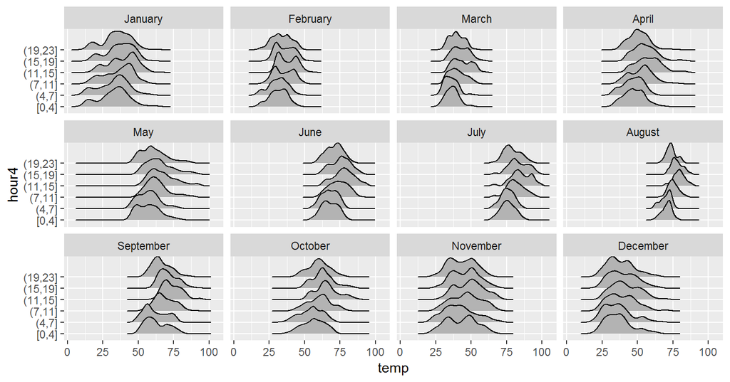

```r
weather_fac %>%
  mutate(hour4 = cut_number(hour, 6) %>% as_factor()) %>%
  ggplot(aes(x=temp, y=hour4)) +
    ggridges::geom_density_ridges() +
    facet_wrap(.~month)
```

## Übung

Erstelle folgende Grafik mit `weather`:

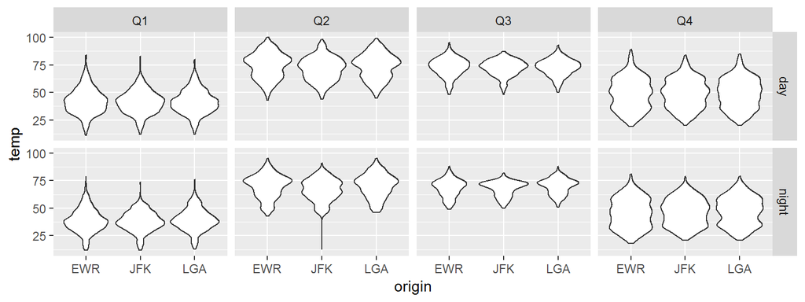

## Lösung:

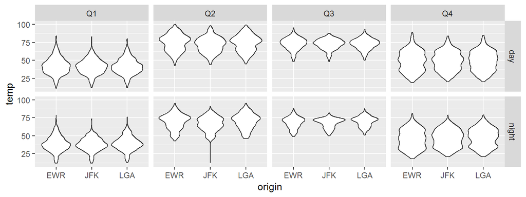

```r
weather %>%
  mutate(quartal = cut_number(month, 4),
         quartal = factor(quartal, labels=paste0("Q",1:4)),
         time = if_else(hour < 5 | hour > 18, "night", "day")
         ) %>%
  ggplot(aes(x=origin, y=temp)) +
    geom_violin() +
    facet_grid(time ~ quartal)
```

## Themes

## Themes

Themes werden für allgemeine Veränderungen des Grafikaussehens verwendet

zB:

- Schrift: Fonts, Größe, Farbe, …
- Legende: Position, Ausrichtung, …
- Elemente: Rand, Hintergrund, …
- Achsen: Farbe, Stärke, …
- …

## Vorgefertigte Themes sind verfügbar

`theme_classic()` entspricht APA Anforderungen sehr gut

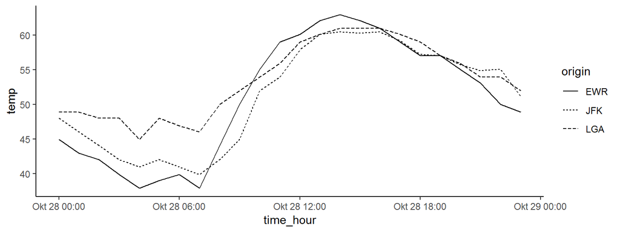

```r
weather %>%
  filter(month==10, day==28) %>%
  ggplot(aes(x=time_hour, y=temp, linetype=origin)) +
    geom_line() +
    theme_classic()
```

## Position der Legende

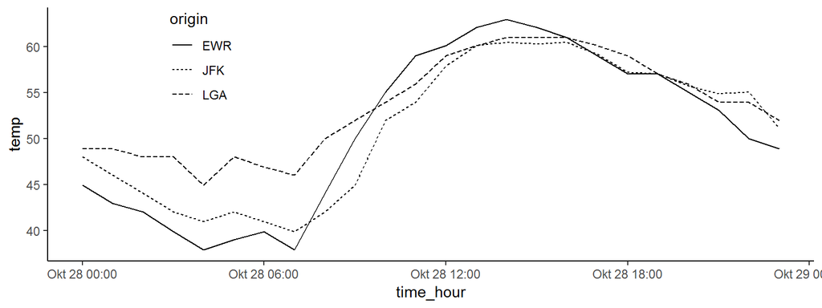

```r
weather %>%
  filter(month==10, day==28) %>%
  ggplot(aes(x=time_hour, y=temp, linetype=origin)) +
    geom_line() +
    theme_classic() +
    theme(
      legend.position = c(0.2, 0.8)
  )
```

## Legendentitel entfernen

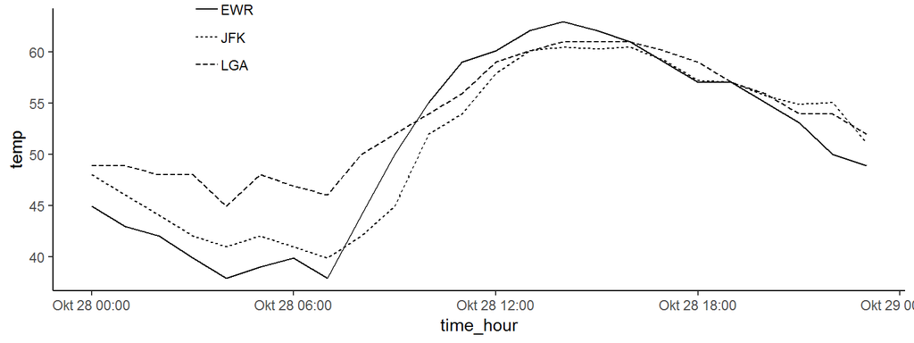

```r
weather %>%
  filter(month==10, day==28) %>%
  ggplot(aes(x=time_hour, y=temp, linetype=origin)) +
    geom_line() +
    theme_classic() +
  theme(
    legend.position = c(0.2, 0.9),
    legend.title = element_blank()
  )
```

## Bonus: Offene Skalen (package: lemon)

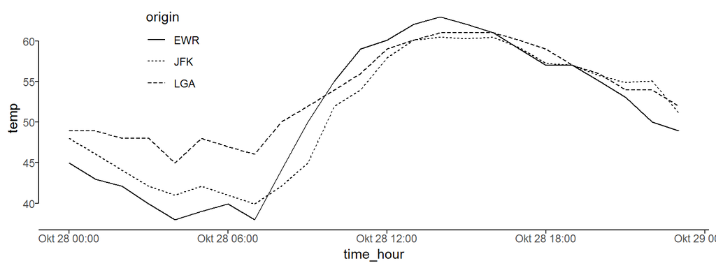

```r
weather %>%
  filter(month==10, day==28) %>%
  ggplot(aes(x=time_hour, y=temp, linetype=origin)) +
    geom_line() +
    lemon::coord_capped_cart(left='both') +
    theme_classic() +
    theme(
      legend.position = c(0.2, 0.8)
  )
```

## Speichern

## ggsave()

`ggsave()` erlaubt das Speichern in unterschiedlichen Formaten

Wähle beim Attribut `filename` einfach entsprechende Datei-Endung

Empfehlung: **pdf** als Vektorgrafik (verlustfrei)

Für nicht Vektorgrafiken (jpg, png, tif, …) kann über `dpi` Auflösung gewählt werden.

`width` und `height` regulieren die Größe

## per Default wird letzte Grafik gespeichert

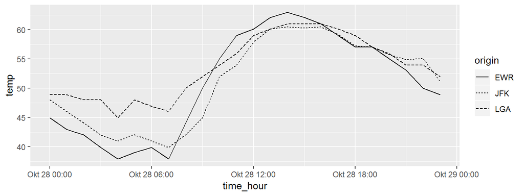

```r
weather %>%
  filter(month==10, day==28) %>%
  ggplot(aes(x=time_hour, y=temp, linetype=origin)) +
    geom_line()
```

```r
ggsave("plots/w2810.pdf", width=18, height=8, units = "cm")
```

## zu speichernde Grafik kann auch gewählt werden

```r
w2810 <- weather %>%
  filter(month==10, day==28) %>%
  ggplot(aes(x=time_hour, y=temp, linetype=origin)) +
    geom_line()

ggsave("plots/w2810.jpg", w2810, width=8, height=5, dpi = 300)
```

## Ressourcen

ggplot2 Anleitungen: [R Graphics Cookbook](http://www.cookbook-r.com/Graphs/)

Grafiken allgemein: [Fundamentals of Data Visualization](https://serialmentor.com/dataviz/)  
(Grafiken mit ggplot2; Code auf github verfügbar)

Interaktive Grafiken: [plotly](https://plot.ly/r/)